# counterfactuals R package

In the following, we explain the `counterfactuals` workflow for both a classification and a regression task using concrete use cases.

```r
library("counterfactuals")
library("iml")
library("randomForest")
library("mlr3")
library("mlr3learners")
```

## Classification Task

To illustrate the `counterfactuals` workflow for classification tasks, we search for counterfactuals with `MOC` (Dandl et al. 2020) for a bank customer, whose credit application is rejected.

### Data: German Credit Dataset

```r
data(german, package = "rchallenge")
credit = german[, c("duration", "amount", "purpose", "age",
  "employment_duration", "housing", "number_credits", "credit_risk")]
```

[output not shown]

### Fitting a model

First, we train a model to predict whether a credit is `good` or `bad`, omitting one observation from the training data, which is `x_interest`.

```r
set.seed(20210816)
rf = randomForest::randomForest(credit_risk ~ ., data = credit[-998L,])
```

### Setting up an iml::Predictor() object

An [`iml::Predictor`](https://giuseppec.github.io/iml/reference/Predictor.html) object serves as a wrapper for different model types. It contains the model and the data for its analysis.

```r
predictor = iml::Predictor$new(rf, type = "prob")
x_interest = credit[998L, ]
predictor$predict(x_interest)
```

```
#>     bad  good
#> 1 0.618 0.382
```

### Find counterfactuals

Now, we examine which factors need to be changed to incrase the predicted probability of being a good credit risk to more than 60%.  
Since we want to apply MOC to a classification model, we initialize a `MOCClassif` object. Individuals whose prediction is farther away from the desired prediction than `epsilon` can be penalized. Here, we set `epsilon = 0`, penalizing all individuals whose prediction is outside the desired interval. With the `fixed_features` argument, we can fix non-actionable features, here `age` and `employment_duration`.

```r
moc_classif = MOCClassif$new(
  predictor, epsilon = 0, fixed_features = c("age", "employment_duration"),
  quiet = TRUE, termination_crit = "genstag", n_generations = 10L
)
```

Then, we use the `find_counterfactuals()` method to find counterfactuals for `x_interest`. As we aim to find counterfactuals with a predicted probability of being a good credit risk of at least 60%, we set the `desired_class` to `"good"` and the `desired_prob` to `c(0.6, 1)`.

```r
cfactuals = moc_classif$find_counterfactuals(
  x_interest, desired_class = "good", desired_prob = c(0.6, 1)
)
```

### The counterfactuals object

The resulting `Counterfactuals` object holds the counterfactuals in the `data` field and possesses several methods for their evaluation and visualization. Printing a `Counterfactuals` object, gives an overview of the results.

```r
print(cfactuals)
```

```
#> 53 Counterfactual(s)
#>
#> Desired class: good
#> Desired predicted probability range: [0.6, 1]
#>
#> Head:
#>    duration amount purpose   age employment_duration housing number_credits
#>       <int>  <int>  <fctr> <int>              <fctr>  <fctr>          <ord>
#> 1:       21   7460  others    30            >= 7 yrs     own              1
#> 2:       21   7054  others    30            >= 7 yrs     own              1
#> 3:       21   6435  others    30            >= 7 yrs     own              1
```

The `predict()` method returns the predictions for the counterfactuals.

```r
head(cfactuals$predict(), 3L)
```

```
#>     bad  good
#> 1 0.322 0.678
#> 2 0.318 0.682
#> 3 0.296 0.704
```

The `evaluate()` method returns the counterfactuals along with the evaluation measures `dist_x_interest`, `dist_target`, `no_changed`, and `dist_train`.  
Setting the `show_diff` argument to `TRUE` displays the counterfactuals as their difference to `x_interest`: for a numeric feature, positive values indicate an increase compared to the feature value in `x_interest` and negative values indicate a decrease; for factors, the counterfactual feature value is displayed if it differs from `x_interest.`; `NA` means “no difference” in both cases.

```r
head(cfactuals$evaluate(show_diff = TRUE,
  measures = c("dist_x_interest", "dist_target", "no_changed", "dist_train")), 3L)
```

```
#>    duration amount purpose   age employment_duration housing number_credits dist_x_interest no_changed dist_train dist_target
#>       <num>  <num>  <char> <num>              <char>  <char>         <char>           <num>      <int>      <num>       <num>
#> 1:       NA  -5220    <NA>    NA                <NA>    <NA>           <NA>      0.04103193          1 0.04215022           0
#> 2:       NA  -5626    <NA>    NA                <NA>    <NA>           <NA>      0.04422330          1 0.03895885           0
#> 3:       NA  -6245    <NA>    NA                <NA>    <NA>           <NA>      0.04908897          1 0.03409318           0
```

By design, not all counterfactuals generated with MOC have a prediction equal to the desired prediction. We can use `subset_to_valid()` to omit all counterfactuals that do not achieve the desired prediction. This step can be reverted with `revert_subset_to_valid()`.

```r
cfactuals$subset_to_valid()
nrow(cfactuals$data)
```

```
#> [1] 22
```

The `plot_freq_of_feature_changes()` method plots the frequency of feature changes across all remaining counterfactuals. Setting `subset_zero = TRUE` removes all unchanged features from the plot.

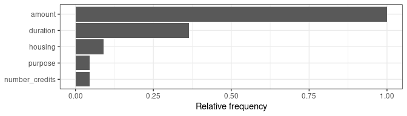

```r
cfactuals$plot_freq_of_feature_changes(subset_zero = TRUE)
```

The parallel plot connects the (scaled) feature values of each counterfactual and highlights `x_interest` in blue. We specify `feature_names` to order the features according to their frequency of changes.

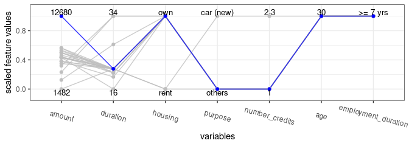

```r
cfactuals$plot_parallel(feature_names = names(
  cfactuals$get_freq_of_feature_changes()), digits_min_max = 2L)
```

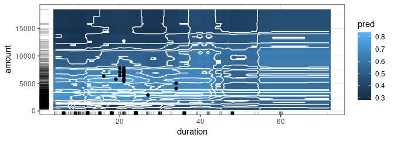

```r
cfactuals$plot_surface(feature_names = c("duration", "amount"))
```

### MOC diagnostics

Additional diagnostic tools for MOC are available as part of the MOCClassif and MOCRegr class. For example, the hypervolume indicator (Zitzler and Thiele 1998) given a reference point (that represents the maximal values of the objectives) could be computed. The evolution of the hypervolume indicator can be plotted together with the evolution of mean and minimum objective values using the `plot_statistics()` method.

```r
moc_classif$plot_statistics(centered_obj = TRUE)
```

[[1]]

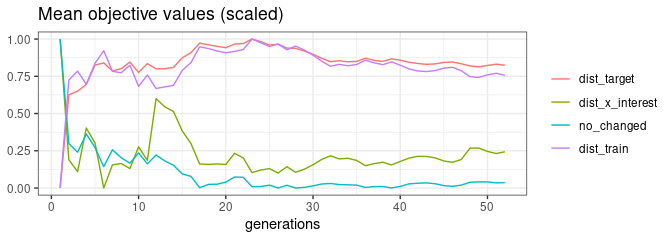

[[2]]

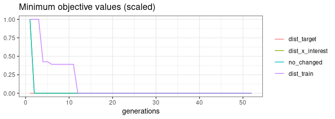

[[3]]

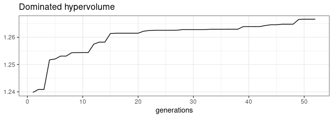

Ideally, one would like the mean value of each objective to decrease over the generations, leading to an increase of the hypervolume. We could visualize the objective values of the emerging candidates throughout the generations via the `plot_search` method for pairs of objectives.

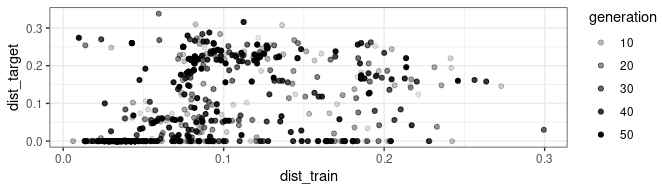

```r
moc_classif$plot_search(objectives = c("dist_train", "dist_target"))
```

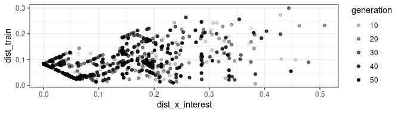

```r
moc_classif$plot_search(objectives = c("dist_x_interest", "dist_train"))
```

## Regression Tasks

### Data: Plasma Retinol

```r
data(plasma, package = "gamlss.data")
```

| Variable | Description |
| --- | --- |
| age | Age (years) |
| sex | Sex (1 = male, 2 = female) |
| smokstat | Smoking status (1 = never, 2 = former, 3 = current smoker) |
| bmi | Body mass index (weight/(height^2)) |
| vituse | Vitamin use (1 = yes, fairly often, 2 = yes, not often, 3 = no) |
| calories | Number of calories consumed per day |
| fat | Grams of fat consumed per day |
| fiber | Grams of fiber consumed per day |
| alcohol | Number of alcoholic drinks consumed per week |
| cholesterol | Cholesterol consumed (mg per day) |
| betadiet | Dietary beta-carotene consumed (mcg per day) |
| retdiet | Dietary retinol consumed (mcg per day) |
| betaplasma | Plasma beta-carotene (ng/ml) |
| retplasma | Plasma retinol (ng/ml) |

### Fitting a model

First, we train a model to predict `plasma_retinol`, again omitting `x_interest` from the training data. This time we use a regression tree trained with the `mlr3` and `rpart` package.

```r
tsk = TaskRegr$new(id = "plasma", backend = plasma[-100L,],
  target = "retplasma")
tree = lrn("regr.rpart")
model = tree$train(tsk)
```

### Setting up an iml::Predictor() object

Then, we initialize an [`iml::Predictor`](https://giuseppec.github.io/iml/reference/Predictor.html) object.

```r
predictor = iml::Predictor$new(model, data = plasma, y = "retplasma")
x_interest = plasma[100L, ]
predictor$predict(x_interest)
```

```
#>   .prediction
#> 1    342.9231
```

For `x_interest`, the model predicts a plasma concentration of 342.92.

### Find counterfactuals

Since we want to apply `NICE` to a regression model, we initialize a `NICERegr` object. For regression models, we define a correctly predicted datapoint when its prediction is less than a user-specified value away. Here we allow for a deviation of `margin_correct = 0.5`. In this example, we aim for proximal counterfactuals in additional to sparse ones, such that we set `optimization = "proximity"`.

```r
nice_regr = NICERegr$new(predictor, optimization = "proximity",
  margin_correct = 0.5, return_multiple = FALSE)
```

Then, we use the `find_counterfactuals()` method to find counterfactuals for `x_interest` with a predicted plasma concentration in the interval [500, Inf).

```r
cfactuals = nice_regr$find_counterfactuals(x_interest,
  desired_outcome = c(500, Inf))
```

### The counterfactuals object

As a result, we obtain a `Counterfactuals` object, just like for the classification task.

```r
cfactuals
```

```
#> 1 Counterfactual(s)
#>
#> Desired outcome range: [500, Inf]
#>
#> Head:
#>      age    sex smokstat      bmi vituse calories   fat fiber alcohol cholesterol betadiet retdiet betaplasma
#>    <int> <fctr>   <fctr>    <num> <fctr>    <num> <num> <num>   <num>       <num>    <int>   <int>      <int>
#> 1:    46      1        3 35.25969      3   2667.5 131.6  10.1       0       550.5     1210    1291        218
```

To inspect the counterfactual, we can use the same tools as before. For example, in the surface plot, we see that increasing betaplasma helps while changing the age alone has no impact on the prediction.

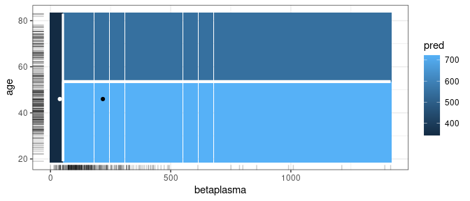

```r
cfactuals$plot_surface(feature_names = c("betaplasma", "age"), grid_size = 200)
```

### User-defined distance function

At the beginning, `NICE` calculates the distance of `x_interest` to each of the training samples. By default, Gower’s distance measures this but users could also specify their own distance functions in the `distance_function` argument. For example, the Gower distance can be replaces by the L_0 norm.

```r
l0_norm = function(x, y, data) {
  res = matrix(NA, nrow = nrow(x), ncol = nrow(y))
  for (i in seq_len(nrow(x))) {
    for (j in seq_len(nrow(y))) {
      res[i, j] = sum(x[i,] != y[j,])
    }
  }
  res
}
```

A short example illustrates the functionality of `l0_norm()`.

```r
xt = data.frame(a = c(0.5), b = c("a"))
yt = data.frame(a = c(0.5, 3.2, 0.1), b = c("a", "b", "a"))
l0_norm(xt, yt, data = NULL)
```

```
#>      [,1] [,2] [,3]
#> [1,]    0    2    1
```

Replacing the distance function is fairly easy:

```r
nice_regr = NICERegr$new(predictor, optimization = "proximity",
  margin_correct = 0.5, return_multiple = FALSE,
  distance_function = l0_norm)
cfactuals = nice_regr$find_counterfactuals(x_interest,
  desired_outcome = c(500, 1000))
cfactuals
```

```
#> 1 Counterfactual(s)
#>
#> Desired outcome range: [500, 1000]
#>
#> Head:
#>      age    sex smokstat      bmi vituse calories   fat fiber alcohol cholesterol betadiet retdiet betaplasma
#>    <int> <fctr>   <fctr>    <num> <fctr>    <num> <num> <num>   <num>       <num>    <int>   <int>      <int>
#> 1:    46      1        3 35.25969      3   2667.5 131.6  10.1       0       550.5     1210    1291        218
```

# References

Dandl, S., Hofheinz, A., Binder, M., Bischl, B., & Casalicchio, C. (2025). “counterfactuals: An R Package for Counterfactual Explanation Methods”. Journal of Statistical Software, 115(9), 1–48.

Dandl, S., Molnar, C., Binder, M., & Bernd Bischl. 2020. “Multi-Objective Counterfactual Explanations”. In: Parallel Problem Solving from Nature – PPSN XVI, edited by Thomas Bäck, Mike Preuss, André Deutz, Hao Wang, Carola Doerr, Michael Emmerich, and Heike Trautmann, 448–469. Cham: Springer International Publishing.

Brughmans, D., & Martens D. (2022). “NICE: An Algorithm for Nearest Instance Counterfactual Explanations.” Technical report, <arXiv:2104.07411> v2

Zitzler, E., & Thiele, L. (1998). “Multiobjective Optimization Using Evolutionary Algorithms—a Comparative Case Study.” In International Conference on Parallel Problem Solving from Nature, 292–301. Springer

Harrell, F. E. (2002). “Plasma Retinol and Beta-Carotene Dataset”. https://hbiostat.org/data/repo/plasma.html